# gaussianComparisons - Final Report

Tyler Brandt, Rohan Gupta, Marcus Hallman, Gangyi Sun

29/04/2018

## Objetive of Project

The data we are working with has to do with user impressions of movie reviews. Users have been shown sets of two comparisons and were asked to pick which one was more positive. If this process is done enough times, you can figure out the order of most positive or negative reviews that you showed the users. The goal of this project is to figure out which two reviews you want to show the next user. By using the [Gaussian Process](http://www.gaussianprocess.org/gpml/chapters/RW.pdf) described by Williams and Rasmussen, we determined the expected information gained by asking the user to choose between two specific reviews. Our maxInfoComp function will make a recommendation for the largest information gain given the data you already have.

## List of all Functions Created

For a list of all functions used in this pacakage and the purpose they serve, refer to README.

## Sample Dataset

The sample dataset is composed of comparisons done on movie reviews. “Comparison” denotes which comparison is being referenced in a given row. “Document” denotes which document is being compared, and “Result” is 1 if the document was more positive than its counterpart. We clean the dataset by placing each compared pair on the same line coding result 1 if the first review was deemed more positive and -1 if the second was deemed more positive.

## Sample Results for Doc ID 5059

**Please set your own working directory in line 39.** The XQuartz package (install from https://www.xquartz.org) is requried for this part of the markdown to compile.

We compare docid 5059 to all other documents in our sample dataset.

The s, mu_hat and rho_squared values are reported. We can see that there there is a strong correlation (R-squared = 0.9796) between s_values and exp(mu_hat).

```
##    doc1 doc2   s_values      mu_hat rho_squared
## 6  5059 5060 0.11486275  0.21157398    111.1607
## 1  5059 5059 0.10444689  0.00000000      8.0000
## 44 5059 5063 0.07959665 -0.05654278    148.5010
## 21 5059 5053 0.07902077 -0.08673825    129.3010
## 16 5059 5054 0.06424752 -0.22673674    122.0045
## 20 5059 5066 0.06395485 -0.22987667    121.3974
```

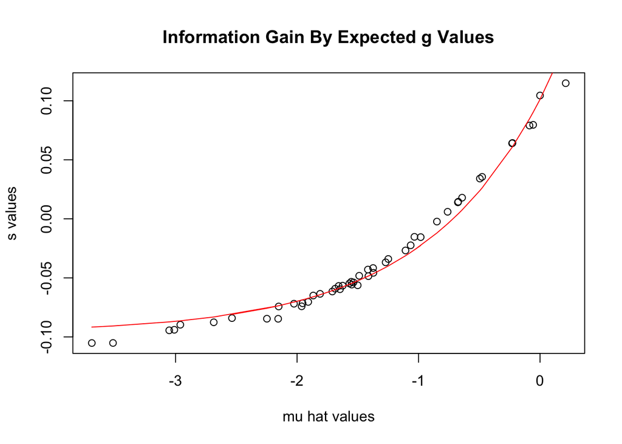

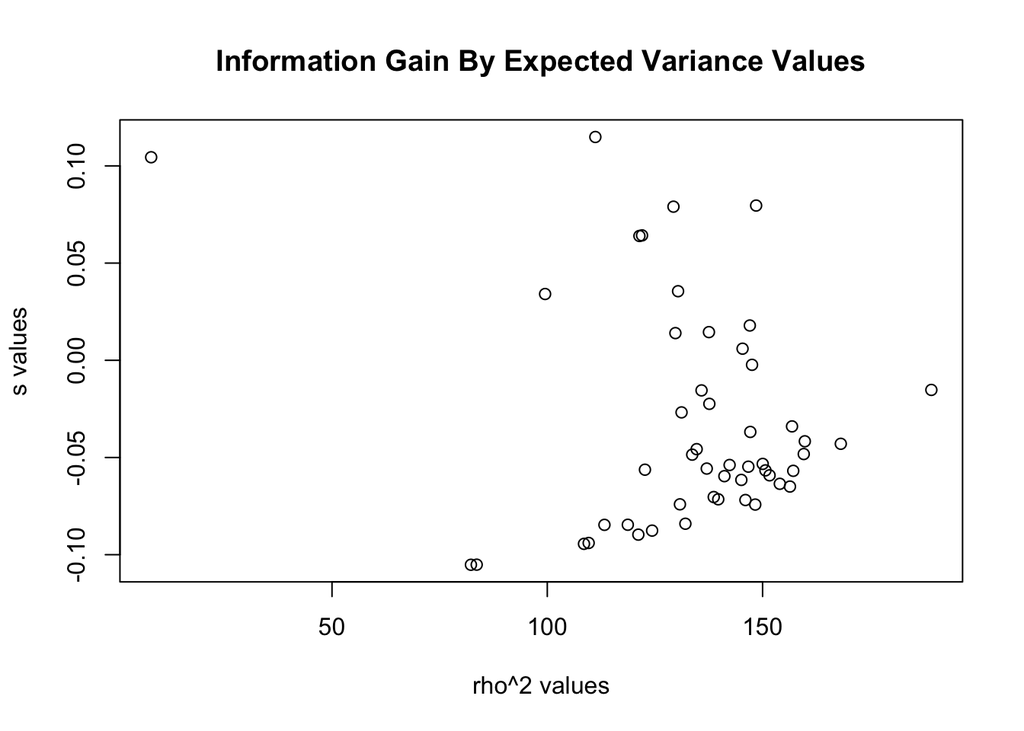